# Assignment 12

Kornel Kovacs

2019 12 06

## General setup for the whole project

```r
df <- read_csv("./hotels-vienna.csv")
```

## Exercise 1

I check the mean of the price in the data.

```r
mean(df$price)
```

```
## [1] 131.3668
```

I am simulating 1 000 samples with replacement and saving their means in a df.

```r
bootstrap_df <- data_frame(num = 1:1000) %>%
    group_by(num) %>%
    mutate(means = mean(sample(df$price, replace = TRUE)))
```

Therefore, the bootstrap standard deviation of this mean (aka ‘the standard error’) can be calculated with ease.

```r
sd(bootstrap_df$means)
```

```
## [1] 4.59712
```

## Exercise 2

I designed the function as the exercise wished.

```r
bootstrap_mean <- function(B,v) {
  bootstrap_df <- data_frame(num = 1:B) %>%
    group_by(num) %>%
    mutate(means = mean(sample(v, replace = TRUE)))
  return(sd(bootstrap_df$means))
}
```

I apply the function on a bunch of values for the plots.

```r
simulated_deviations <- unlist(pblapply(2:1000, bootstrap_mean, v=df$price))
df_to_plot <- data.frame(number_of_simulations = 2:1000,
                         standard_dev = simulated_deviations)
```

This is the first way of visualisation. It shows standard deviations as a function of how many values we simulate. We can see a nice funnel-like pattern.

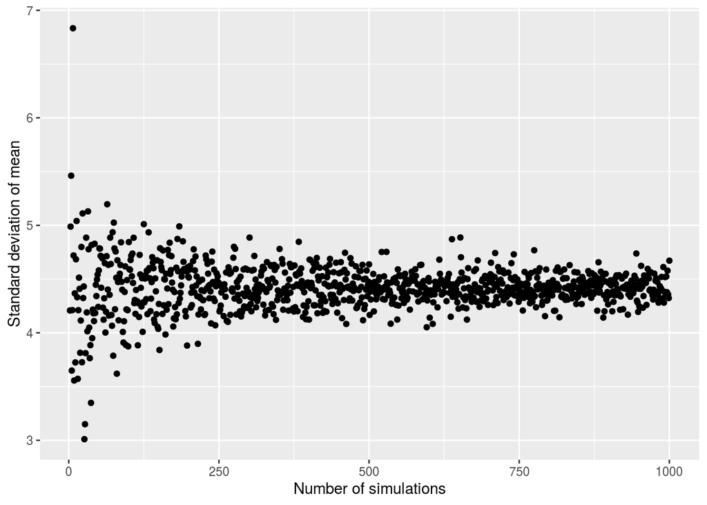

```r
ggplot(df_to_plot, aes(x = number_of_simulations, y = standard_dev)) +
  geom_point() +
  xlab("Number of simulations") +
  ylab("Standard deviation of mean")
```

A histogram of the standard deviations gives you a hint about the distribution of values. It seems to be normally distributed.

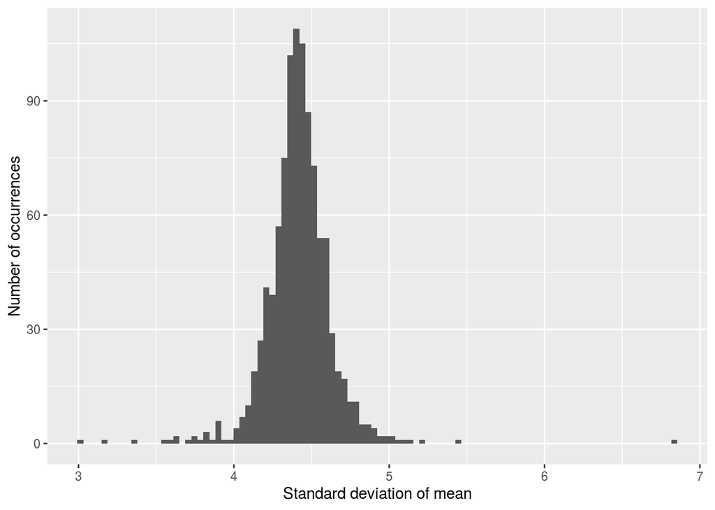

```r
ggplot(df_to_plot, aes(x=standard_dev)) +
  geom_histogram(bins = 100) +
  ylab("Number of occurrences") +
  xlab("Standard deviation of mean")
```

## Exercise 3

I found a nice package called `plotrix` which has a function that calculates the standard error for mean `price`.

```r
std.error(df$price)
```

```
## [1] 4.426713
```

If you are conservative and do not like to use new packages, you may also compute the same result manually.

```r
(conservative_std_error <- sd(df$price)/sqrt(length(df$price)))
```

```
## [1] 4.426713
```

## Exercise 4

I define the function to calculate standard deviation for median values.

```r
bootstrap_median <- function(B,v) {
  bootstrap_df <- data_frame(num = 1:B) %>%
    group_by(num) %>%
    mutate(medians = median(sample(v, replace = TRUE)))
  return(sd(bootstrap_df$medians))
}
```

I also try it out.

```r
bootstrap_median(1000, df$price)
```

```
## [1] 3.116337
```

## Exercise 5

I defined my Swiss army knife, a multifunctional method. I had to differentiate between DFs and vectors because their sampling functions are named slightly different.

```r
bootstrap_func <- function(B,v, method) {
  if (is.data.frame(v)) {
    bootstrap_df <- data_frame(num = 1:B) %>%
    group_by(num) %>%
    mutate(metric_value = method(sample_n(v, nrow(v), replace = TRUE)))
    return(sd(bootstrap_df$metric_value))
  } else {
    bootstrap_df <- data_frame(num = 1:B) %>%
    group_by(num) %>%
    mutate(metric_value = method(sample(v, replace = TRUE)))
    return(sd(bootstrap_df$metric_value))
  }
}
```

Example calls:

```r
bootstrap_func(1000, df$price, sd)
```

```
## [1] 12.34059
```

```r
bootstrap_func(1000, df$price, max)
```

```
## [1] 160.5091
```

```r
bootstrap_func(1000, df$price, mean)
```

```
## [1] 4.397964
```

```r
bootstrap_func(1000, df$price, median)
```

```
## [1] 3.107792
```

As we do not have a basic function for the top quartile, some hacking is needed for this case.

```r
bootstrap_func(1000, df$price,function(metric) quantile(metric)[4])
```

```
## [1] 5.104662
```

## Exercise 6

I define the function that returns the adequat value of the regression.

```r
get_coeff <- function(data){
  mod <- lm(price ~ distance_alter, data = data)
  return(summary(mod)$coefficients[2, 1])
}
```

I use the above as an input for the general function. This should return the standard error.

```r
bootstrap_func(1000, df, get_coeff)
```

```
## [1] 1.822463
```

## Exercise 7

```r
mod <- lm(price ~ distance_alter, data = df)
summary(mod)
```

```
##
## Call:
## lm(formula = price ~ distance_alter, data = df)
##
## Residuals:
##    Min     1Q Median     3Q    Max
## -95.99 -46.56 -22.31  14.77 881.36
##
## Coefficients:
##                Estimate Std. Error t value Pr(>|t|)
## (Intercept)     164.444     10.903  15.083   <2e-16 ***
## distance_alter   -8.895      2.686  -3.312    0.001 **
## ---
## Signif. codes:  0 '***' 0.001 '**' 0.01 '*' 0.05 '.' 0.1 ' ' 1
##
## Residual standard error: 90.53 on 426 degrees of freedom
## Multiple R-squared:  0.02511,    Adjusted R-squared:  0.02282
## F-statistic: 10.97 on 1 and 426 DF,  p-value: 0.001004
```